# MLDS 401 (Fall 2023) - Lab 1 Solution

Yayu Zhou

2023-09-26

## [2.10] Price elasticities of steaks

```r
data1 = read.csv("~/Personal Drive/Northwestern University/Fall 2023/MLDS 401 - TA/Labs/steakprices.csv") %>%
  mutate_at(vars(Chuck.Price, PortHse.Price, RibEye.Price), ~as.numeric(gsub("\\$", "", .)))
```

The power law $y = ax^b$ is used to model the demand-price relationship in economies, and $b$ represents the price elasticity of the demand for the product. Following are plots for $\log{Q}$ versus $\log{P}$ of all three steaks.

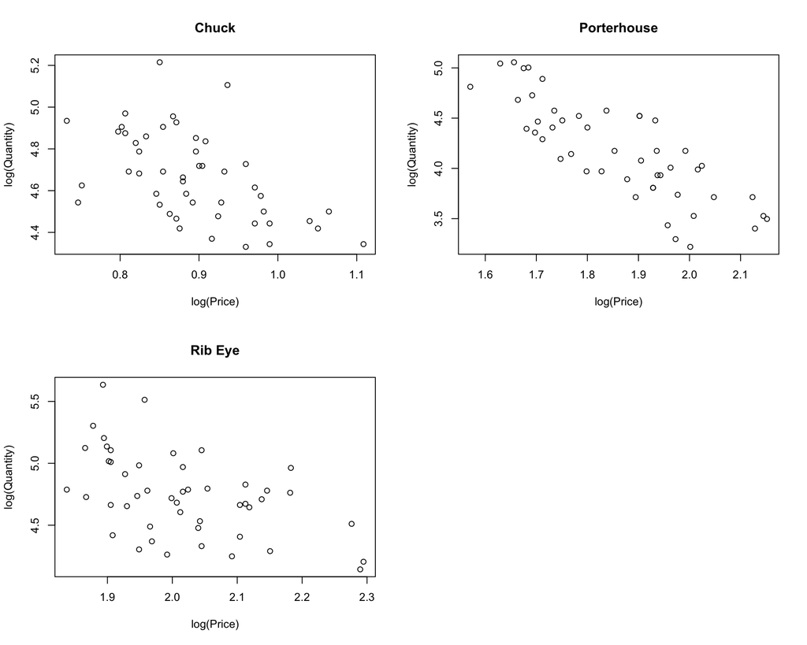

```r
par(mfrow = c(2, 2))
plot(log(data1$Chuck.Price), log(data1$Chuck.Qty), xlab = "log(Price)", ylab = "log(Quantity)", main = "Chuck")
plot(log(data1$`PortHse.Price`), log(data1$`PortHse.Qty`), xlab = "log(Price)", ylab = "log(Quantity)", main = "Porterhouse")
plot(log(data1$`RibEye.Price`), log(data1$`RibEye.Qty`), xlab = "log(Price)", ylab = "log(Quantity)", main = "Rib Eye")
```

According to the above scatter plots, for all three types of steaks, the data follow a (negative) linear relationship between $\log{Q}$ and $\log{P}$. Thus, we fitted the model:
$$\ln{Q} = \ln{a} + b\ln{P}$$

### a)

```r
fit_chuck = lm(log(Chuck.Qty) ~ log(Chuck.Price), data = data1)
fit_ph = lm(log(PortHse.Qty) ~ log(PortHse.Price), data = data1)
fit_rib = lm(log(RibEye.Qty) ~ log(RibEye.Price), data = data1)
summary(fit_chuck)
```

```
##
## Call:
## lm(formula = log(Chuck.Qty) ~ log(Chuck.Price), data = data1)
##
## Residuals:
##      Min       1Q   Median       3Q      Max
## -0.32463 -0.12036 -0.01714  0.09430  0.49725
##
## Coefficients:
##                  Estimate Std. Error t value Pr(>|t|)
## (Intercept)        5.8899     0.2871  20.513  < 2e-16 ***
## log(Chuck.Price)  -1.3687     0.3199  -4.278 9.44e-05 ***
## ---
## Signif. codes:  0 '***' 0.001 '**' 0.01 '*' 0.05 '.' 0.1 ' ' 1
##
## Residual standard error: 0.1812 on 46 degrees of freedom
## Multiple R-squared:  0.2846, Adjusted R-squared:  0.2691
## F-statistic:  18.3 on 1 and 46 DF,  p-value: 9.441e-05
```

```r
summary(fit_ph)
```

```
##
## Call:
## lm(formula = log(PortHse.Qty) ~ log(PortHse.Price), data = data1)
##
## Residuals:
##      Min       1Q   Median       3Q      Max
## -0.57655 -0.23544  0.00317  0.23511  0.49991
##
## Coefficients:
##                    Estimate Std. Error t value Pr(>|t|)
## (Intercept)          9.1123     0.5136  17.742  < 2e-16 ***
## log(PortHse.Price)  -2.6565     0.2752  -9.654 1.23e-12 ***
## ---
## Signif. codes:  0 '***' 0.001 '**' 0.01 '*' 0.05 '.' 0.1 ' ' 1
##
## Residual standard error: 0.283 on 46 degrees of freedom
## Multiple R-squared:  0.6695, Adjusted R-squared:  0.6624
## F-statistic:  93.2 on 1 and 46 DF,  p-value: 1.233e-12
```

```r
summary(fit_rib)
```

```
##
## Call:
## lm(formula = log(RibEye.Qty) ~ log(RibEye.Price), data = data1)
##
## Residuals:
##      Min       1Q   Median       3Q      Max
## -0.54075 -0.21801  0.03995  0.20328  0.70950
##
## Coefficients:
##                   Estimate Std. Error t value Pr(>|t|)
## (Intercept)         7.6627     0.7537  10.167 2.39e-13 ***
## log(RibEye.Price)  -1.4460     0.3731  -3.876 0.000335 ***
## ---
## Signif. codes:  0 '***' 0.001 '**' 0.01 '*' 0.05 '.' 0.1 ' ' 1
##
## Residual standard error: 0.2943 on 46 degrees of freedom
## Multiple R-squared:  0.2462, Adjusted R-squared:  0.2298
## F-statistic: 15.02 on 1 and 46 DF,  p-value: 0.0003352
```

To estimate the price elasticity is to estimate $b$. Results are summarized as following:

| Steaks | Price Elasticity Estimates | P-values |
| --- | --- | --- |
| Chuck | -1.3687 | 9.44e-05 *** |
| Porterhouse | -2.6565 | 1.23e-12 *** |
| Rib Eye | -1.446 | 0.000335 *** |

### b)

If the price is increased by 10% then chuck demand will drop by 13.69%, the porter demand by 26.57% and the rib eye demand by 14.46%.

## [2.11] Smoking vs. Cancer

### a) Scatter Plots

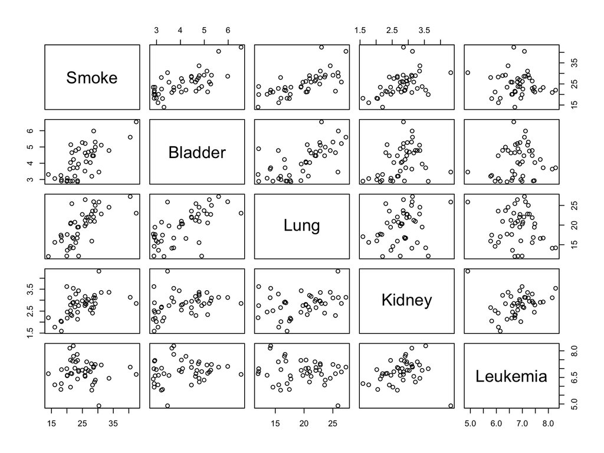

```r
data2 = read.csv("~/Personal Drive/Northwestern University/Fall 2023/MLDS 401 - TA/Labs/smoking-cancer.csv")
plot(data2[, -1])
```

### b) Correlation Tests

```r
testB = cor.test(x = data2$Smoke, y = data2$Bladder)
testL = cor.test(x = data2$Smoke, y = data2$Lung)
testK = cor.test(x = data2$Smoke, y = data2$Kidney)
testLK = cor.test(x = data2$Smoke, y = data2$Leukemia)
```

Performed tests on the correlations $H_{0}: \rho = 0$. The significance level is $\alpha = 0.05$ and 95% confidence intervals are computed. All the results were summarized as following:

| Cancer | r | t statistic | p-value | 95% CI |
| --- | --- | --- | --- | --- |
| Bladder | 0.7036 | 6.4173 | 0 | (0.5141, 0.8276) |
| Lung | 0.6974 | 6.3064 | 0 | (0.5051, 0.8237) |
| Kidney | 0.4874 | 3.6174 | 8e-04 | (0.2227, 0.6851) |
| Leukemia | -0.0685 | -0.4449 | 0.6587 | (-0.3581, 0.2331) |

From all four types of cancer, only Leukemia has p-value$> 0.05$, and its 95% confidence interval includes 0, so Leukemia is not significantly correlated with cigarette smoking. Among other three cancers that are significantly correlated with smoking, Bladder has the smallest p-value, and greatest correlation coefficient in magnitude (the closest r to 1). Therefore, **Bladder** is the most significantly correlated with cigarette smoking.

## Question 3

```r
x = c(5.8, 8.8, 11.0, 13.6, 18.5, 21.0, 23.7, 26.0, 28.3, 31.9, 36.5, 38.2, 40.4)
y = c(7.8, 8.2, 6.9, 5.3, 4.7, 4.9, 4.3, 2.7, 2.8, 1.8, 1.9, 1.1, 0.4)

n = length(x)
xtotal = sum(x)
ytotal = sum(y)
Sxx = (n - 1) * var(x)
Sxy = (n - 1) * cov(x, y)
Syy = (n - 1) * var(y)
xbar = mean(x)
ybar = mean(y)

fit = lm(y ~ x)
```

### a) Linear Equation

```r
beta1 = Sxy/Sxx
beta0 = ybar - beta1 * xbar
```

$\hat{\beta}_1 = \dfrac{S_{xy}}{S_{xx}} = -0.2157$ and $\hat{\beta}_0 = \bar{y} - \hat{\beta}_1 \bar{x} = 9.101$. Then our line is $\hat{y} = 9.101 - 0.2157 x$.

We can check the result from linear regression:

```r
summary(fit)
```

```
##
## Call:
## lm(formula = y ~ x)
##
## Residuals:
##      Min       1Q   Median       3Q      Max
## -0.86726 -0.41025  0.01393  0.31147  0.99731
##
## Coefficients:
##             Estimate Std. Error t value Pr(>|t|)
## (Intercept)  9.10099    0.36634   24.84 5.16e-11 ***
## x           -0.21572    0.01418  -15.22 9.80e-09 ***
## ---
## Signif. codes:  0 '***' 0.001 '**' 0.01 '*' 0.05 '.' 0.1 ' ' 1
##
## Residual standard error: 0.5645 on 11 degrees of freedom
## Multiple R-squared:  0.9546, Adjusted R-squared:  0.9505
## F-statistic: 231.5 on 1 and 11 DF,  p-value: 9.805e-09
```

### b) Prediction for $x = 25$

```r
x0 = 25
ypred1 = beta0 + beta1 * x0
predict(fit, newdata = data.frame(x = 25))
```

```
##        1
## 3.708097
```

$$\hat{y} = 9.101 - 0.2157 \times 25 =
3.7081$$
.

### c) Prediction for $x = 45$

```r
x0 = 45
ypred2 = beta0 + beta1 * x0
predict(fit, newdata = data.frame(x = 45))
```

```
##          1
## -0.6062183
```

$$\hat{y} = 9.101 - 0.2157 \times 45 =
-0.6062$$
.

Our maximum $x$ value in our sample is 40.4, so 45 is outside our calculation and because of that our solution is not trustworthy.

### d) $R^2$

```r
r = Sxy/sqrt(Sxx * Syy)
r2 = r^2
```

$$r = \frac{S_{xy}}{\sqrt{S_{xx}S_{yy}}} =
\frac{-341.9592}{\sqrt{1,585.231 \times 77.2708}} = -0.9771$$
and then $R^{2} = r^2 = 0.9546$. We can explain 95% of the variation in the data with the known values of x.

```r
sigma2 = (1 - r2) * Syy/(n-2)
se_beta1 = sqrt(sigma2 / Sxx)
ci = beta1 + c(-1, 1) * qt(1 - 0.01/2, df = n - 2) * se_beta1
confint(fit)
```

```
##                  2.5 %     97.5 %
## (Intercept)  8.2946906  9.9072895
## x           -0.2469194 -0.1845121
```

From class, we know
$$r^2 =
1-\frac{\text{SSE}}{\text{SST}} \implies \text{SSE}= (1- r^2)\text{SST}=
(1 - r^2)S_{yy}$$
$$\sigma^2 =
\text{MSE}= \frac{\text{SSE}}{n - 2} = \frac{(1 - r^2)S_{yy}}{n - 2} =
0.3186$$
$$S_{\hat{\beta}_1} =
\sqrt{\frac{\sigma^2}{S_{xx}}} = 0.0142$$

### f) 95% CI for $\hat{y}$ at $x = 25$

```r
x0 = 25
sigma = sqrt(sigma2)
se_ypred = sigma * sqrt(1/n + (x0 - xbar)^2/Sxx)
ci = ypred1 + c(-1, 1) * qt(1 - 0.05/2, df = n - 2) * se_ypred
predict(fit, newdata = data.frame(x = 25), interval = "confidence")
```

```
##        fit      lwr     upr
## 1 3.708097 3.359753 4.05644
```

$$S_{\hat{y}|x_0} =
\sigma\sqrt{\frac{1}{n} + \frac{(\bar{x}- x_0)^2}{S_{xx}}} =
0.1583$$

### g) 95% PI for $\hat{y}$ at $x = 25$

```r
x0 = 25
se_ypred2 = sigma * sqrt(1 + 1/n + (x0 - xbar)^2/Sxx)
ci = ypred1 + c(-1, 1) * qt(1 - 0.05/2, df = n - 2) * se_ypred2
predict(fit, newdata = data.frame(x = 25), interval = "prediction")
```

```
##        fit      lwr      upr
## 1 3.708097 2.417814 4.998379
```

$$S_{Y|x_0} = \sigma\sqrt{1 + \frac{1}{n}
+ \frac{(\bar{x}- x_0)^2}{S_{xx}}} = 0.5862$$